# Simulation 5: g-formula with varying reliability

Brian Richardson

11/26/2024

```r
rm(list = ls())
library(dplyr)
library(tidyverse)
library(ggplot2)
library(ggh4x)
library(kableExtra)
library(devtools)
load_all()
```

```r
# load simulation results from each of 10 clusters
setwd(dirname(getwd()))
sim.out.list <- lapply(
  X = 0:9,
  FUN = function(clust) {
    cbind(clust,
          read.csv(paste0("sim_data/sim5_gfmla_reliability/sd",
                          clust, ".csv")))
  })

# combine simulation results into 1 data frame
sim.out <- bind_rows(sim.out.list)

# true estimands
g <- c(0, 0.25, 0.5, -0.5, 1)          # outcome model parameters
a <- -1:2                                        # exposure value of interest
EYa.true <- g[1] + 0.5*g[5] + a*g[2] + a^2*g[3] + a^3*g[4]

# number of sims per setting
n.rep <- nrow(sim.out) / n_distinct(dplyr::select(sim.out, n, B, rel))

# make long data frame
sim.out.long <- sim.out %>%
  pivot_longer(cols = starts_with("est") |
                      starts_with("ste") |
                      starts_with("bcs"),
               names_to = "method.aa",
               values_to = "val") %>%
    mutate(method = factor(substr(method.aa, 5, 6),
                           levels = c("NG", "CG"),
                           labels = c("Naive G-Formula",
                                      "G-Formula CS")),
           aa = factor(substr(method.aa, 8, 8)),
           a = factor(a[aa]),
           name = factor(substr(method.aa, 1, 3)),
           EYa.true = EYa.true[aa],
           rel.lab = factor(rel,
                            labels = round(unique(rel), 2))) %>%
  dplyr::select(-method.aa) %>%
  group_by(clust, n, B, rel, rel.lab, method, aa, a, name) %>%
  mutate(id = row_number()) %>%
  pivot_wider(names_from = name,
              values_from = val,
              id_cols = c(clust, n, B, rel, rel.lab, method, aa, a, EYa.true, id)) %>%
  mutate(ci.lower = est - qnorm(0.975) * ste,
         ci.upper = est + qnorm(0.975) * ste,
         ci.cov = EYa.true >= ci.lower & EYa.true <= ci.upper,
         bcci.lower = est - qnorm(0.975) * bcs,
         bcci.upper = est + qnorm(0.975) * bcs,
         bcci.cov = EYa.true >= bcci.lower & EYa.true <= bcci.upper)
```

The goal of this program is to evaluate the G-formula CS estimator with a nonlinear outcome model and for a sequence of exposure reliability values.

## Setup

This data generating process leads to a mean potential outcome at $a$ of $\textrm{E}\{Y(a)\} = 0.5 + 0.25a + 0.5a^2 - 0.5a^3$.

The estimand of interest in these simulations is the dose response curve $\{\textrm{E}[Y(a)] : a \in \mathcal{A}\}$.

## Methods

In these simulations, we compare two methods:

1. Naive G-Formula
2. CS G-Formula

The naive method treats $A^*$ as $A$, assuming there is no measurement error. The CS method uses the Monte-Carlo corrected score versions of the estimating functions.

## Results

We first check for simulations with errors.

```r
# summarize proportion of missing data by setting
sim.out.long %>%
  filter(aa == 1) %>%
  group_by(method, n, B, rel.lab) %>%
  summarise(prop.error = mean(is.na(est))) %>%
  filter(prop.error > 0)
```

```
## # A tibble: 0 × 5
## # Groups:   method, n, B [0]
## # ℹ 5 variables: method <fct>, n <int>, B <int>, rel.lab <fct>,
## #   prop.error <dbl>
```

```r
# extract simulation parameters
n <- unique(sim.out$n)

# make labels for plots
method.labs <- c("Naive G-Formula",
                 "G-Formula CS")

names(method.labs) <- c("NG", "CG")

n.labs <- paste0("n = ", n)
names(n.labs) <- n

a.labs <- paste0("a = ", a)
names(a.labs) <- a

# colorblind friendly pallette
pal_light <- c('#EE6677', '#228833', '#4477AA', '#CCBB44', '#66CCEE', '#AA3377', '#BBBBBB')
pal_dark <- c('#991122', '#114419', '#223b55', '#6b611d', '#117799', '#55193b', '#5d5d5d')
```

```r
# create plots
make.plot <- function(title = F, a. = 1, rel.min = 0.5, y.lim = Inf) {

  plot <- sim.out.long %>%
    filter(aa == a.,
           rel.lab >= rel.min) %>%
    mutate(rel.lab = factor(rel.lab)) %>%
    ggplot(aes(x = rel.lab, y = est, group = rel.lab)) +
    geom_boxplot(width = 0.7, outlier.size = 0.5) +
    geom_hline(aes(yintercept = EYa.true),
               linetype = "dashed",
               color = "orange") +
    facet_grid(n ~ method,
               scales = "free",
               labeller = labeller(n = n.labs)) +
    labs(y = "Parameter Estimate",
         x = "Exposure Reliability",
         fill = "Method",
         color = "Method") +
    theme_bw() +
    theme(legend.position = "bottom") +
    scale_x_discrete()


  if (title) {
    plot <- plot +
      ggtitle(paste0("Empirical Distribution of Parameter Estimates"),
              subtitle = paste0(n.rep, " simulations per setting"))

  }
  return(plot)
}
```

```r
# create plots
make.plot <- function(title = F, a. = 1, rel.min = 0, y.lim = Inf) {

  # Calculate the counts of truncated values
  truncated_data <- sim.out.long %>%
    filter(aa == a., rel >= rel.min) %>%
    group_by(rel.lab, n, method) %>%
    summarize(
      above = sum(est - EYa.true > y.lim),
      below = sum(est - EYa.true < -y.lim)
    ) %>%
    ungroup()

  # Merge the truncated counts with the original data
  sim.out.long.with.labels <- sim.out.long %>%
    filter(aa == a., rel >= rel.min) %>%
    left_join(truncated_data, by = c("rel.lab", "n", "method")) %>%
    mutate(
      above.lab = ifelse(above == 0, "", as.character(above)),
      below.lab = ifelse(below == 0, "", as.character(below)))

  # Create the plot
  plot <- sim.out.long.with.labels %>%
    filter(abs(est - EYa.true) < y.lim) %>%
    ggplot(aes(x = rel.lab)) +
    geom_boxplot(
      aes(y = est, group = as.factor(rel)),
      width = 0.7, outlier.size = 0.5) +
    geom_hline(
      aes(yintercept = EYa.true),
      linetype = "dashed", color = "orange") +
    geom_text(
      aes(y = EYa.true + y.lim + .3, label = above.lab),
      size = 3,
      color = "red"
    ) +
    geom_text(
      aes(y = EYa.true - y.lim - .3, label = below.lab),
      size = 3,
      hjust = 0.5,
      color = "red"
    ) +
    facet_grid(n ~ method,
               labeller = labeller(n = n.labs)) +
    labs(
      y = "Parameter Estimate",
      x = "Exposure Reliability",
      fill = "Method",
      color = "Method"
    ) +
    theme_bw() +
    theme(legend.position = "bottom")

  if (title) {
    plot <- plot +
      ggtitle(paste0("Empirical Distribution of Parameter Estimates"),
              subtitle = paste0(n.rep, " simulations per setting"))

  }
  return(plot)
}
```

```r
# create plots
make.plot.2 <- function(title = F, a. = 1, rel.min = 0) {

  plot <- sim.out.long %>%
    filter(aa == a.,
           rel >= rel.min) %>%
    pivot_longer(cols = ends_with(".cov"),
                 names_to = "ci.type",
                 values_to = "ci.cov") %>%
    mutate(ci.type = ifelse(ci.type == "bcci.cov",
                            "Bias-Corrected",
                            "Uncorrected")) %>%
    group_by(rel, n, method, ci.type) %>%
    summarise(cov = mean(ci.cov, na.rm = T)) %>%
    ggplot(aes(x = rel,
               linetype = ci.type,
               y = cov)) +
    geom_line() +
    geom_hline(yintercept = 0.95,
               linetype = "dashed",
               color = "orange") +
    facet_grid(n ~ method,
               scales = "free",
               labeller = labeller(n = n.labs)) +
    labs(y = "Coverage Probability",
         x = "Exposure Reliability",
         linetype = "CI Type") +
    theme_bw() +
    theme(legend.position = "bottom")

  if (title) {
    plot <- plot +
      ggtitle(paste0("Empirical Coverage Probabilities of 95% Confidence Intervals"),
              subtitle = paste0(n.rep, " simulations per setting"))

  }
  return(plot)
}
```

### Plots of Simulation Results

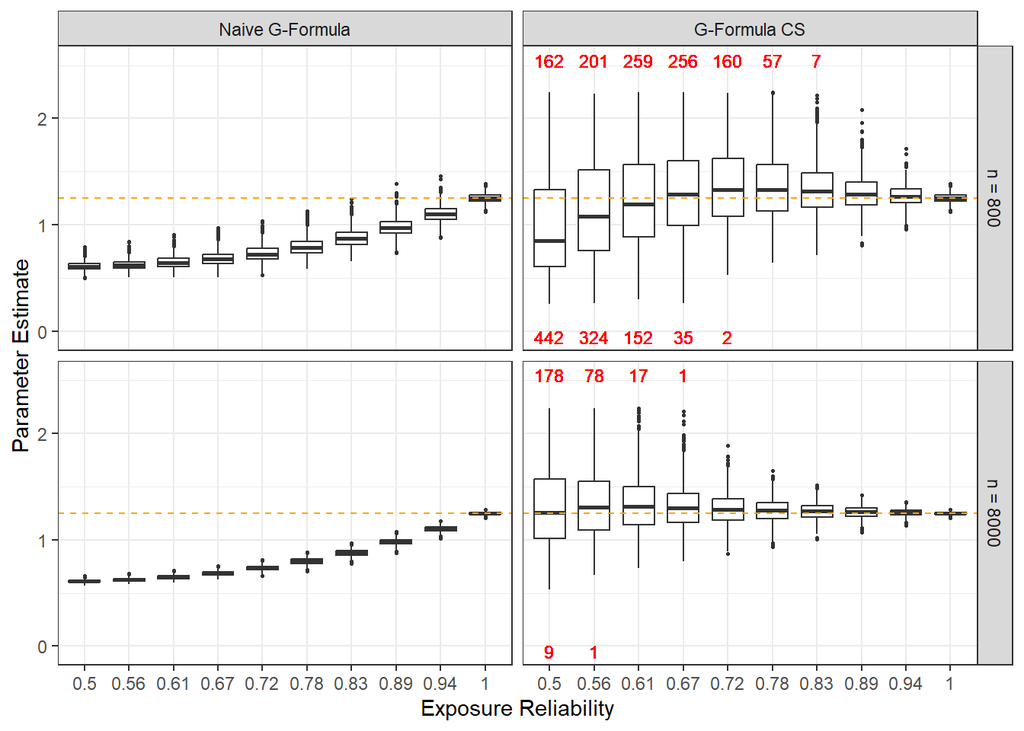

```r
make.plot(y.lim = 1)
```

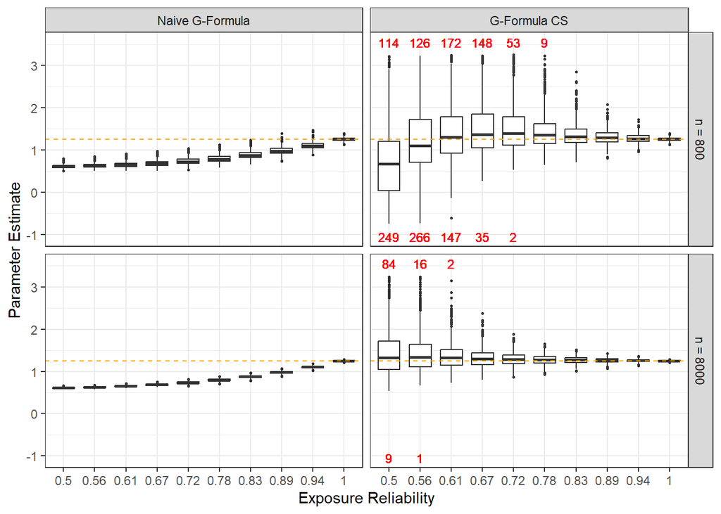

```r
make.plot(y.lim = 2)
```

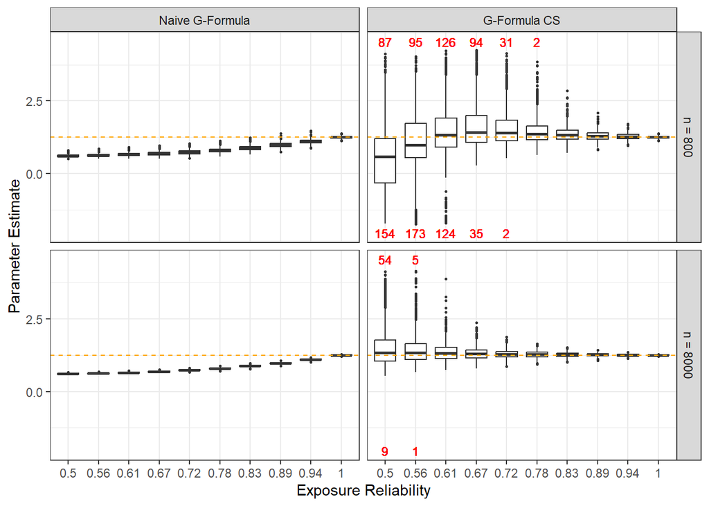

```r
make.plot(y.lim = 3)
```

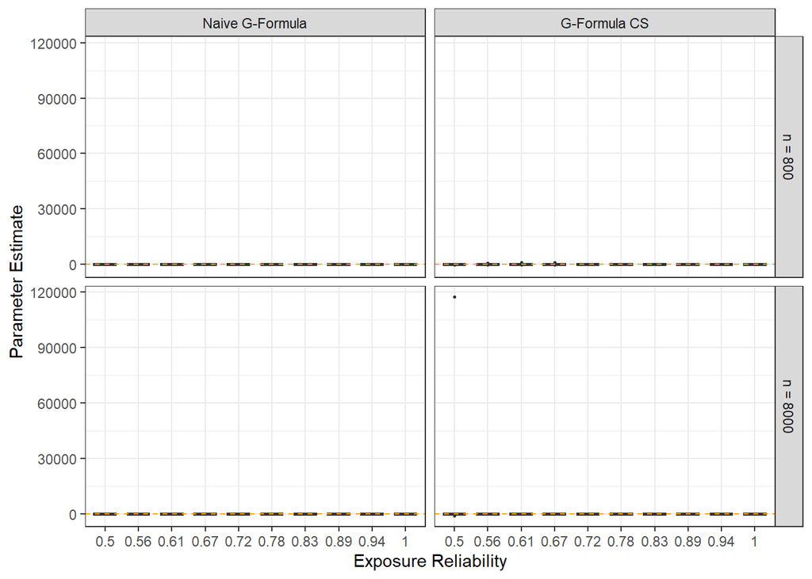

```r
make.plot()
```

```r
# save plot
setwd(dirname(getwd()))
ggsave("sim_figures/sim5_gfmla_reliability_1.png",
       width = 6,
       height = 4,
       dpi = 300)
```

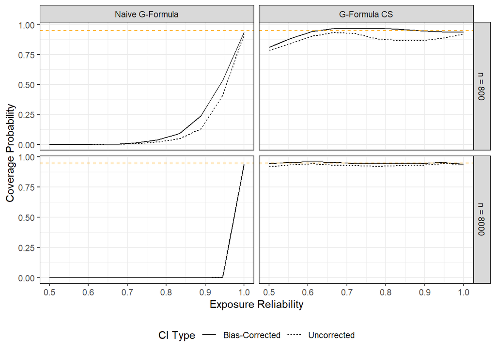

```r
make.plot.2()
```

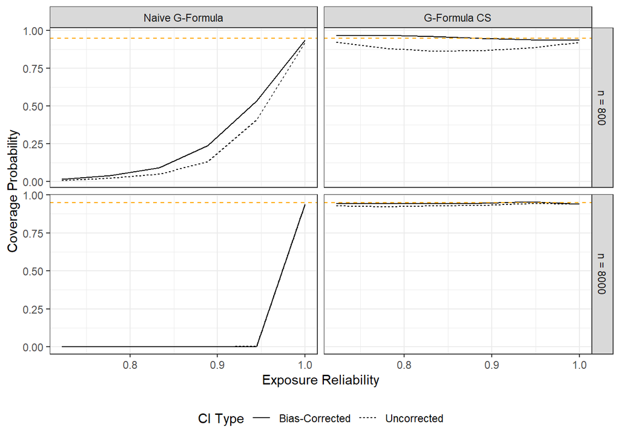

```r
make.plot.2(rel.min = 0.7)
```

```r
# save plot
setwd(dirname(getwd()))
ggsave("sim_figures/sim5_gfmla_reliability_2.png",
       width = 6,
       height = 4,
       dpi = 300)
```